# Covid analyses

2023-04-08

## Covid overview

To start this analysis we download a data set from John Hopkins found on this website: https://github.com/CSSEGISandData/COVID-19/tree/master/csse_covid_19_data/csse_covid_19_time_series Then we cleaned the set to facilitate the analyses. We remove columns that wouldn’t be used for analyses and also rows with negative values for cases since you can’t have negative covid cases. Finally, we end up with 2 main datasets: Global(all cases and deaths), US(all US cases and deaths).

## Summary

Then we ran a summary from all data sets, so we could see the bigger picture. The data runs from 2020 to 2023.

```r
summary(global)
```

```
##  Province.State     Country.Region          date                cases
##  Length:330327      Length:330327      Min.   :2020-01-22   Min.   :        0
##  Class :character   Class :character   1st Qu.:2020-11-02   1st Qu.:      680
##  Mode  :character   Mode  :character   Median :2021-08-15   Median :    14429
##                                        Mean   :2021-08-15   Mean   :   959384
##                                        3rd Qu.:2022-05-28   3rd Qu.:   228517
##                                        Max.   :2023-03-09   Max.   :103802702
##      deaths
##  Min.   :      0
##  1st Qu.:      3
##  Median :    150
##  Mean   :  13380
##  3rd Qu.:   3032
##  Max.   :1123836
```

```r
summary(Us)
```

```
##       UID              Admin2          Province_State     Country_Region
##  Min.   :      16   Length:3819903     Length:3819903     Length:3819903
##  1st Qu.:84018105   Class :character   Class :character   Class :character
##  Median :84029205   Mode  :character   Mode  :character   Mode  :character
##  Mean   :83429922
##  3rd Qu.:84046119
##  Max.   :84099999
##  Combined_Key            date                cases           Population
##  Length:3819903     Min.   :2020-01-22   Min.   :      0   Min.   :       0
##  Class :character   1st Qu.:2020-11-02   1st Qu.:    330   1st Qu.:    9917
##  Mode  :character   Median :2021-08-15   Median :   2272   Median :   24909
##                     Mean   :2021-08-14   Mean   :  14088   Mean   :   99604
##                     3rd Qu.:2022-05-28   3rd Qu.:   8159   3rd Qu.:   64979
##                     Max.   :2023-03-09   Max.   :3710586   Max.   :10039107
##      deaths
##  Min.   :    0.0
##  1st Qu.:    4.0
##  Median :   37.0
##  Mean   :  186.9
##  3rd Qu.:  122.0
##  Max.   :35545.0
```

## Star plotting

We start our analyses to see how the pandemic behaved in the last couple of years. We gather the data set based on the date to facilitate the analyses. Then, we observe new cases and new deaths from around the world and the US.

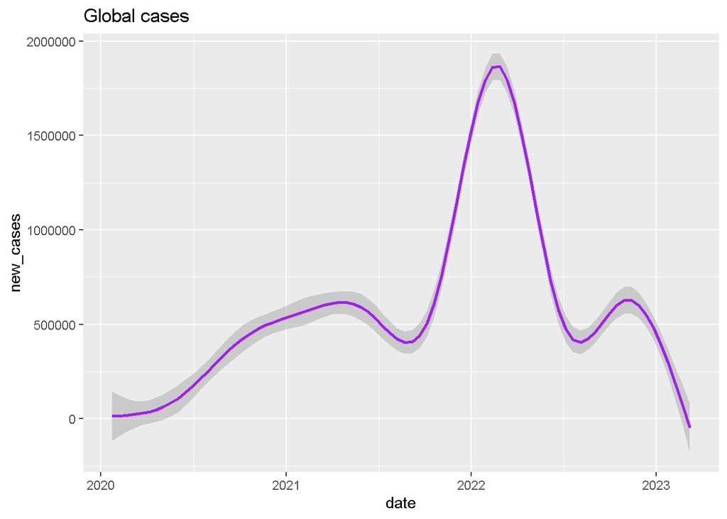

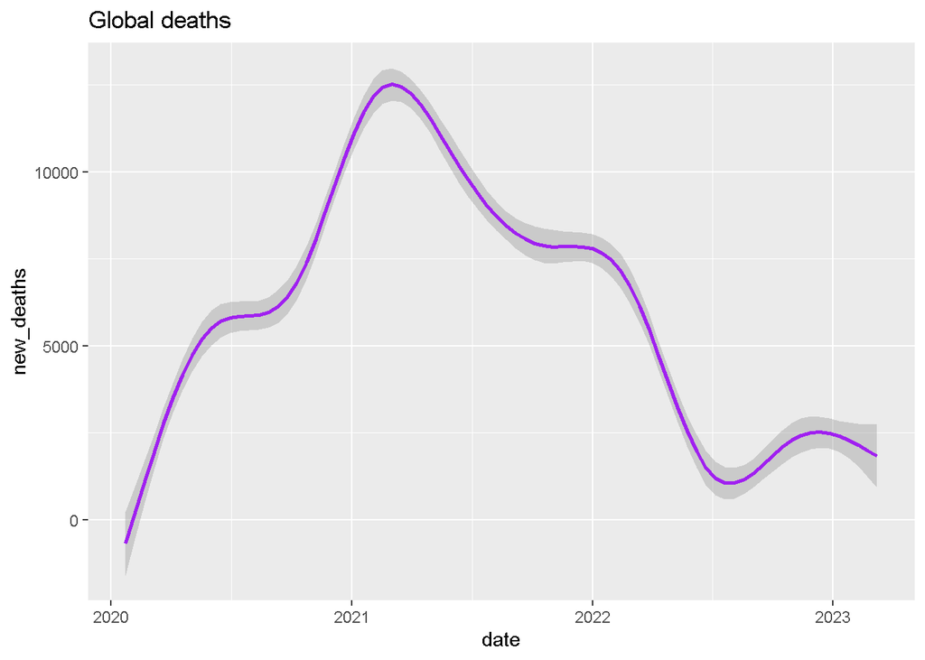

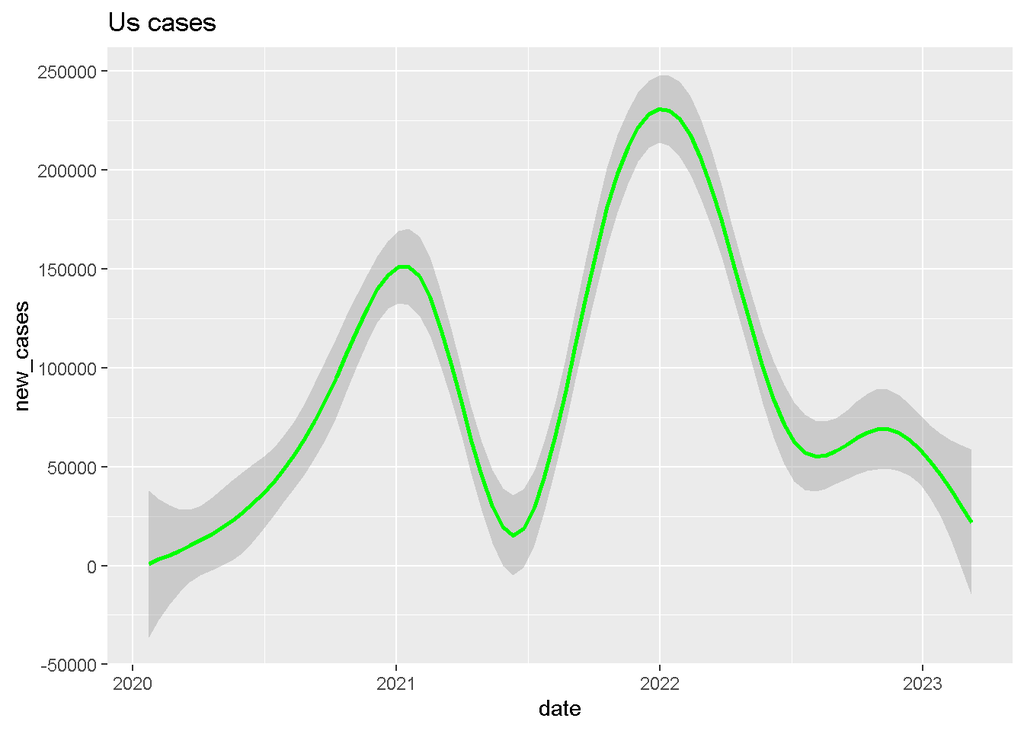

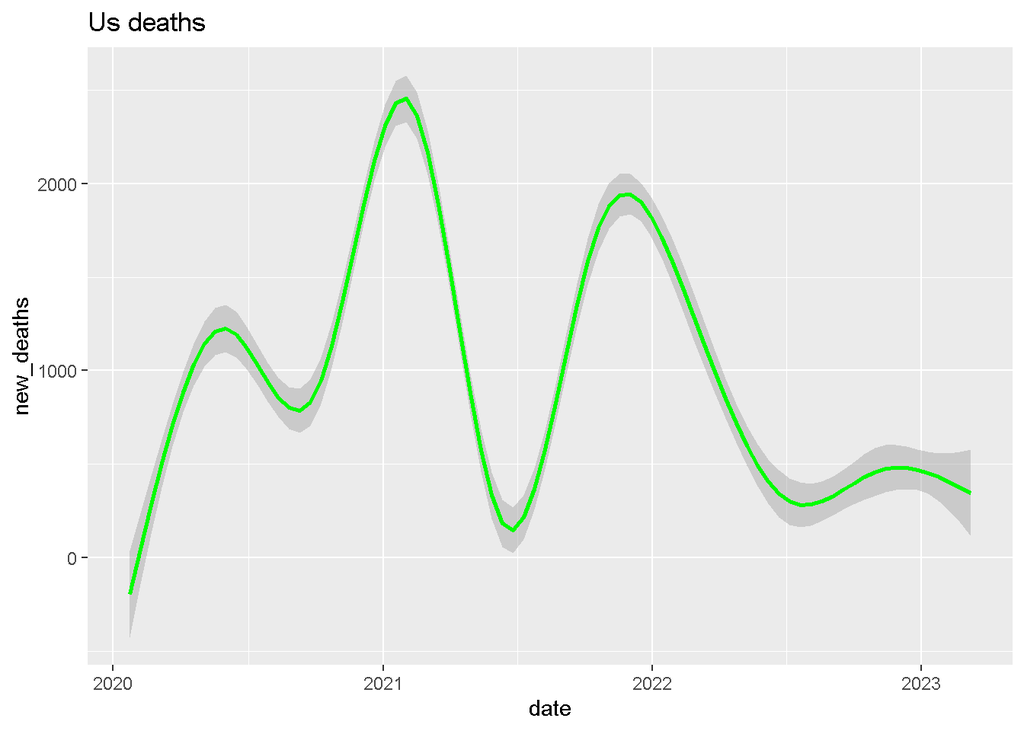

It is possible to point out how the graphics have waves that intensify during the years, especially in 2022. A couple of new variants of the disease can explain that. We can also observe that both the Global data and the US data have their peaks of death in 2021, having some waves after that, but never reaching the same level. The Covid vaccine was launched at the end 2020 and spread along in 2021, so that could be an explanation.

The second part of our analysis was to observe the number of cases and deaths in each state of the US. To keep our analyses clean, we created a data set group by each state and only observed the states with more than the mean in each statistic.

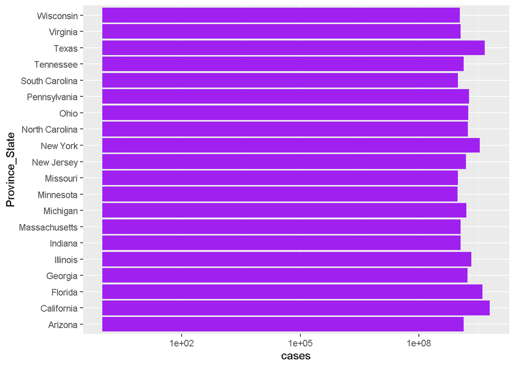

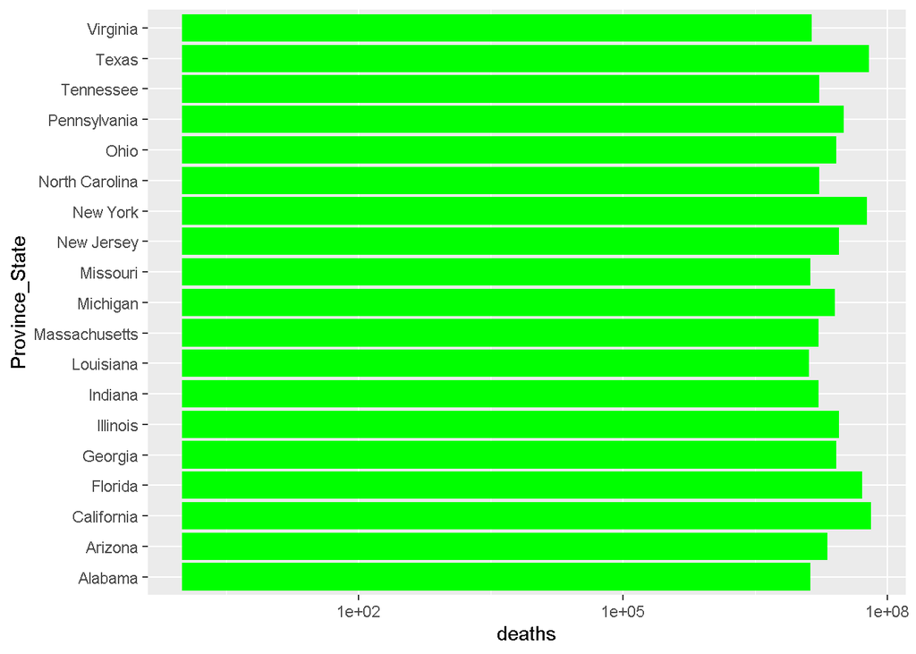

It was possible to observe that Texas and California had the highest overall number of cases in the country. This was, somehow, expected considering that they are the second and third biggest states in the US. However, when observing the number of deaths, New York is at the same level as both states.

## Modeling

Another interesting analysis would be to relate the number of cases with the number of deaths and observe if they grow in a linear patter. However, the projection was way off, showing that there isn’t a direct relationship between these 2 sets of data.

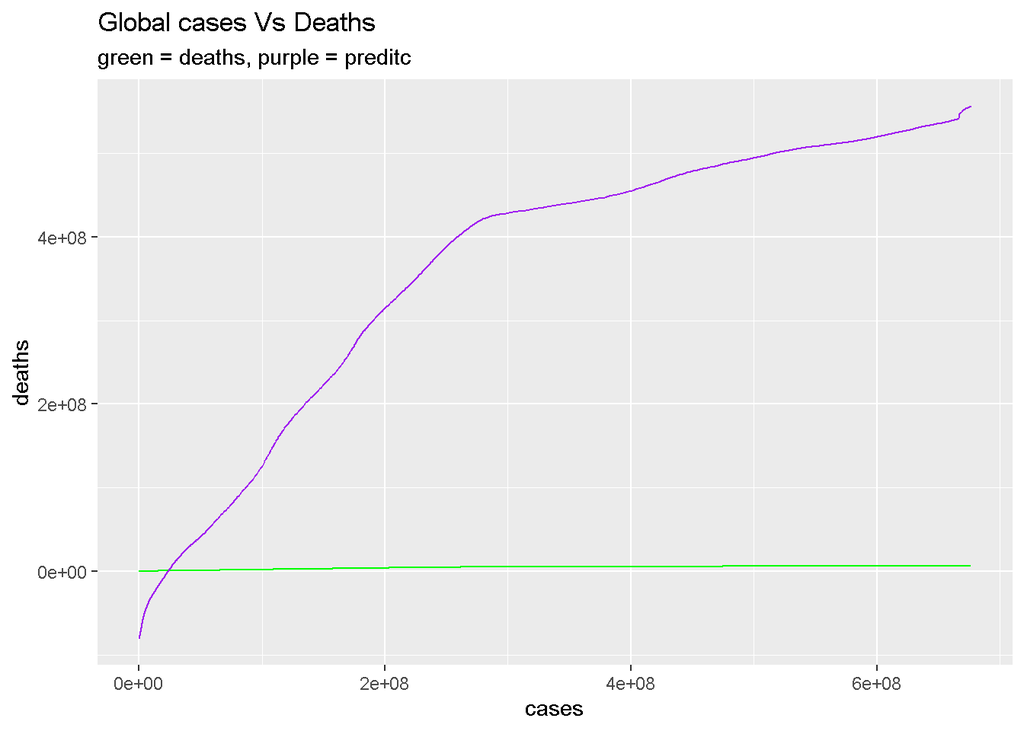

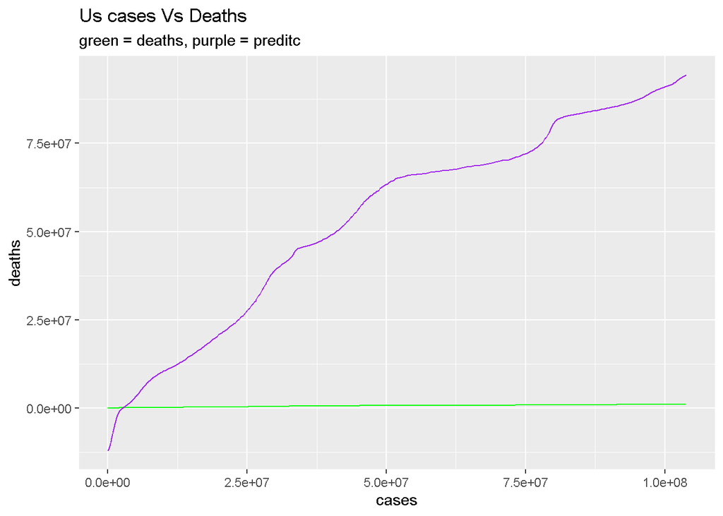

## Bias

When talking about Covid, it is important to keep in mind that this data is self-reported, therefore, the number of cases is based on people who first took the test. Secondly, they informed authorities that they tested positive. With the at-home tests, it became more and more difficult to be sure if the numbers are accurate. Another important fact to keep in mind is that it is hard to guarantee that someone died of covid or from complications from other diseases. For example, a person who has asthma for their lifetime and dies after contracting Covid is a victim of the illness, but maybe would survive under different conditions. Without a clear profile of the victims, it is hard guarantee that the data is not biased.

## Conclusions

The Covid pandemic changed the world and understanding the data surrounding this phenomenon is crucial. A couple of observations could be made from the data. First, the number of new cases have come in waves. Secondly, the fact that the number of new deaths reduced significantly since the vaccination effort started is a good indication that the vaccines are working. We can also say that the states with the most cases are, for the most part, the ones with the most deaths. Lastly, it is possible to conclude that cases and deaths don’t have a linear correlation.